# Lesson 4

```r
setwd("D:/IIML/Crisp Analytics/Udacity/DAta analysis with R/")
```

### Scatterplots and Perceived Audience Size

Notes:

### Scatterplots

Notes:

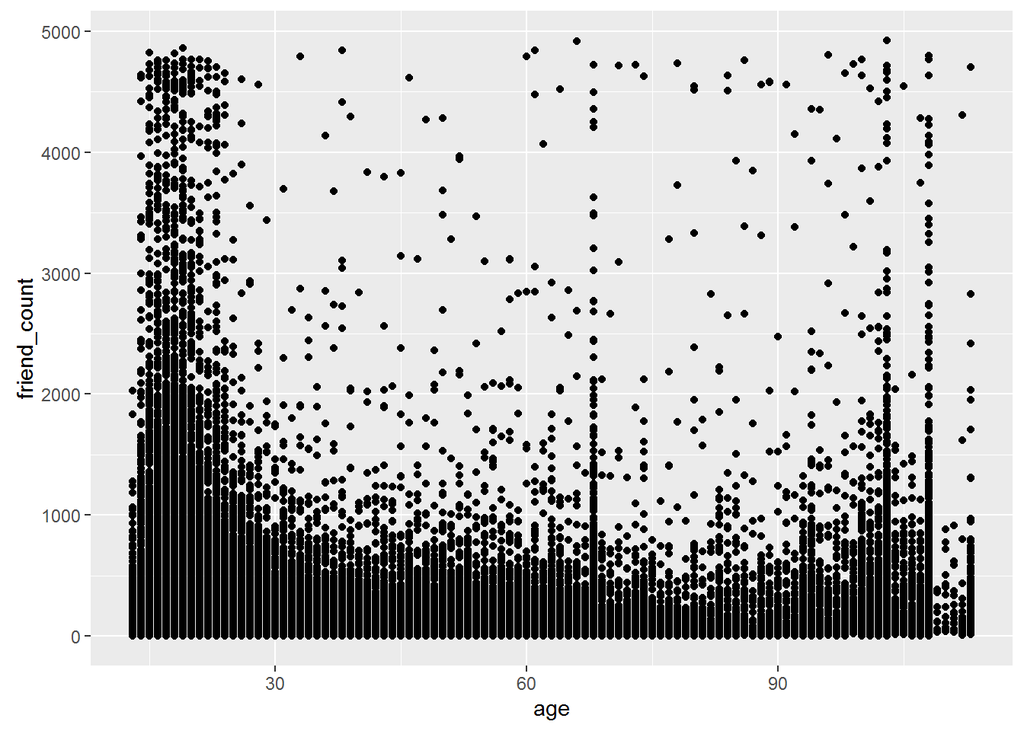

```r
library(ggplot2)
pf <- read.csv("pseudo_facebook.tsv", sep = "\t")
View(pf)
qplot(x = age, y = friend_count, data = pf)
```

#### What are some things that you notice right away?

Response: * Younger Users have lots of friends * Vertical bars that people have lied about their age like 69 and 100. These accounts tend to be of teenagers or fake accounts given the high number of friends.

### ggplot Syntax

Notes: * aes - aesthatic wrapper holds x and y variables. * Limiting the x - axes from 13-90 years since users younger than 13 cannot have fb account and over 90 years of age those are supposedly fake accounts.

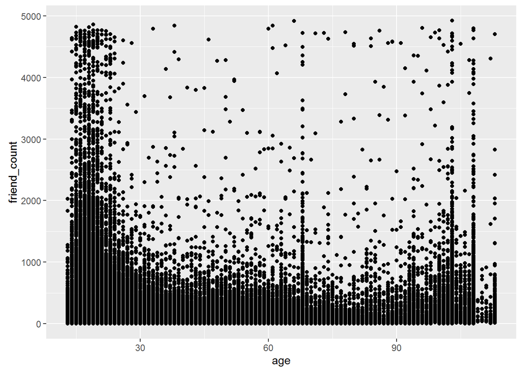

```r
ggplot(pf, aes(age, friend_count)) + geom_point()
```

```r
summary(pf$age)
```

```
##    Min. 1st Qu.  Median    Mean 3rd Qu.    Max.
##   13.00   20.00   28.00   37.28   50.00  113.00
```

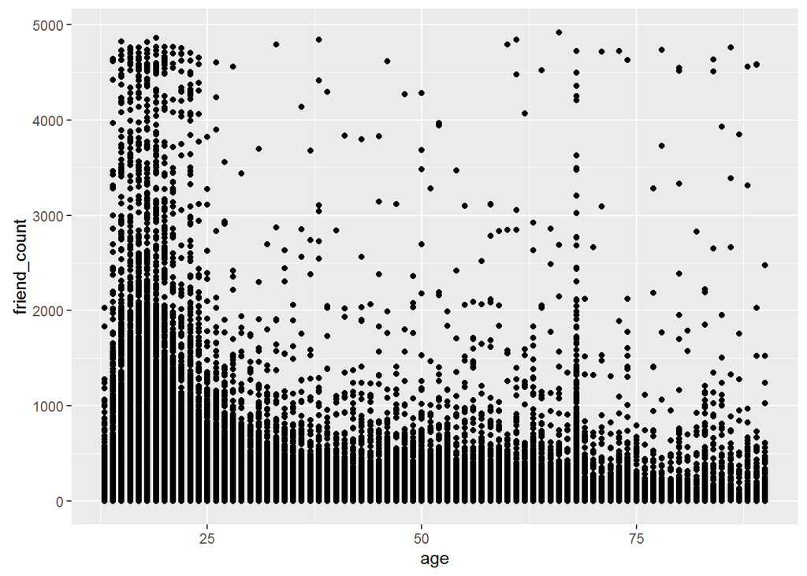

```r
#Limiting the axes
ggplot(pf, aes(age, friend_count)) + geom_point() + xlim(13,90)
```

### Overplotting

Notes: Overplotting means that observations are stacked over one another and it is difficult to tell the exact number of obervations. The densely populated areas is the area that is overplotted. The issue can be resolved by changing the transparecny

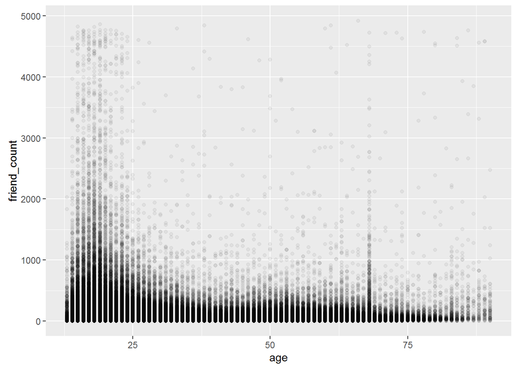

```r
# The alpha param controls transparency.
ggplot(pf, aes(age, friend_count)) +
  geom_point(alpha = 1/20) +
  xlim(13,90)
```

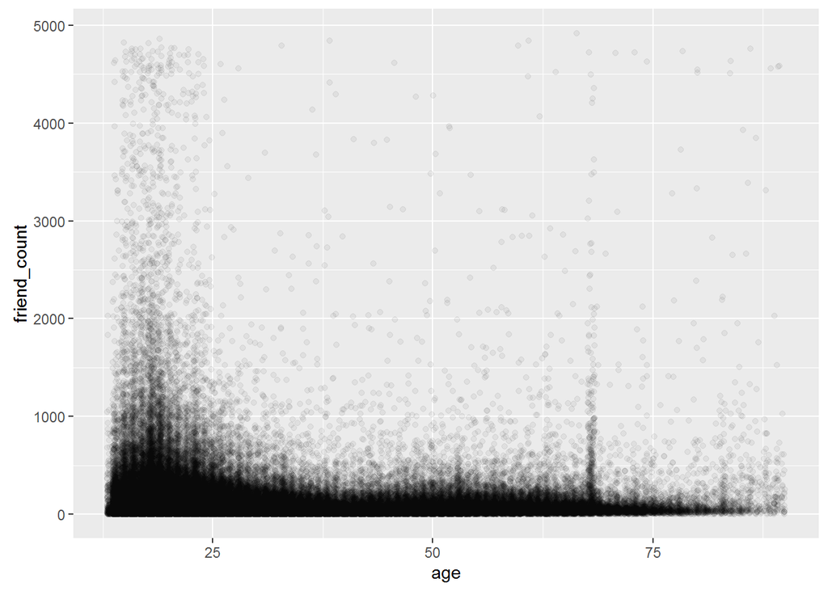

```r
# Using geom_jitter to make the age continous
ggplot(pf, aes(age, friend_count)) +
  geom_jitter(alpha = 1/20) +
  xlim(13,90)
```

#### What do you notice in the plot?

Response: * Bulk of the data lies below 1000 friend count. ***

### Coord_trans()

Notes:

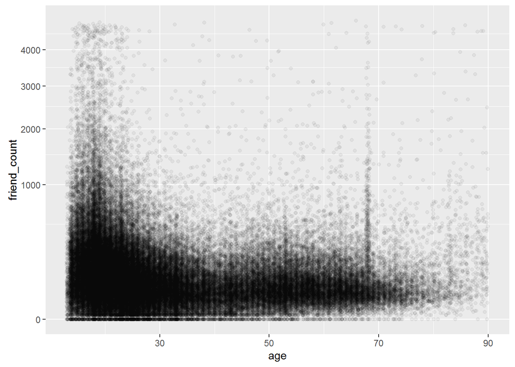

```r
ggplot(pf, aes(age, friend_count)) +
  geom_point(alpha = 1/20, position = position_jitter(h = 0)) +
  xlim(13,90) +
  coord_trans(y = "sqrt")
```

#### Look up the documentation for coord_trans() and add a layer to the plot that transforms friend_count using the square root function. Create your plot!

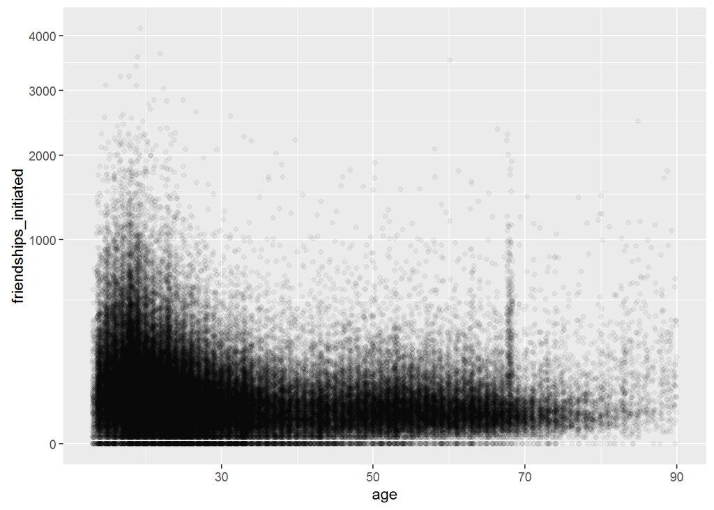

```r
ggplot(pf, aes(age, friendships_initiated)) +
  geom_point(alpha = 1/20, position = position_jitter(h = 0)) +
  xlim(13,90) +
  coord_trans(y = "sqrt")
```

### Overplotting and Domain Knowledge

Notes:

### Conditional Means

Notes: Analysing the variation of mean friend count over age groups makes much more sense than plotting actual data and reading from them.

```r
library(dplyr)
# some of the common functions of dplyr package are filter(), group_by(), mutate() and arrange()
# Lets group the users by age
age_groups <- group_by(pf, age)
# Summarize the data we just created and find the mean, median and number of users in each age groups
pf.fc_by_age <- summarise(age_groups,
                          friend_count_mean = mean(friend_count),
                          friend_count_median = median(friend_count),
                          n = n())
head(pf.fc_by_age)
```

```
## # A tibble: 6 x 4
##     age friend_count_mean friend_count_median     n
##   <int>             <dbl>               <dbl> <int>
## 1    13          164.7500                74.0   484
## 2    14          251.3901               132.0  1925
## 3    15          347.6921               161.0  2618
## 4    16          351.9371               171.5  3086
## 5    17          350.3006               156.0  3283
## 6    18          331.1663               162.0  5196
```

```r
# The data is not in any order - so arrange will help order the age groups
pf.fc_by_age <- arrange(pf.fc_by_age, age)
```

## ANOTHER WAY

### Above code may be verbose so another way of getting the same table

```r
# '%.%' lets us chain functions
# pf.fc_by_age2 <- pf %>%
#   group_by(age) %>%
#   summarise(age_groups,
#             friend_count_mean = mean(friend_count),
#             friend_count_median = median(friend_count),
#             n = n()) %>%
#   arrange(age)
```

Create your plot!

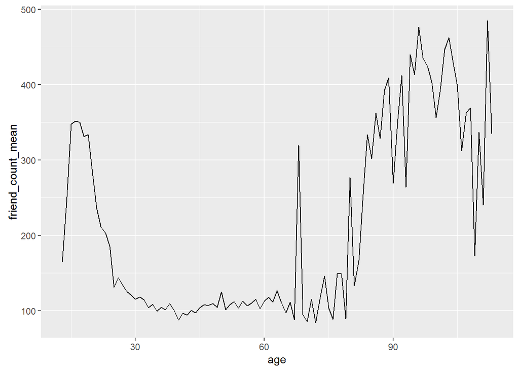

```r
ggplot(pf.fc_by_age, aes(age, friend_count_mean)) + geom_line()
```

### Overlaying Summaries with Raw Data

Notes: ggplot 2.0.0 changes the syntax for parameter arguments to functions when using stat = ‘summary’. To denote parameters that are being set on the function specified by fun.y, use the fun.args argument, e.g.: geom_line(stat = ‘summary’, fun.y = quantile, fun.args = list(probs = .9), … )

To zoom in, the code should use thecoord_cartesian(xlim = c(13, 90)) layer rather than xlim(13, 90) layer.

Look up documentation for coord_cartesian() and quantile() if you’re unfamiliar with them.

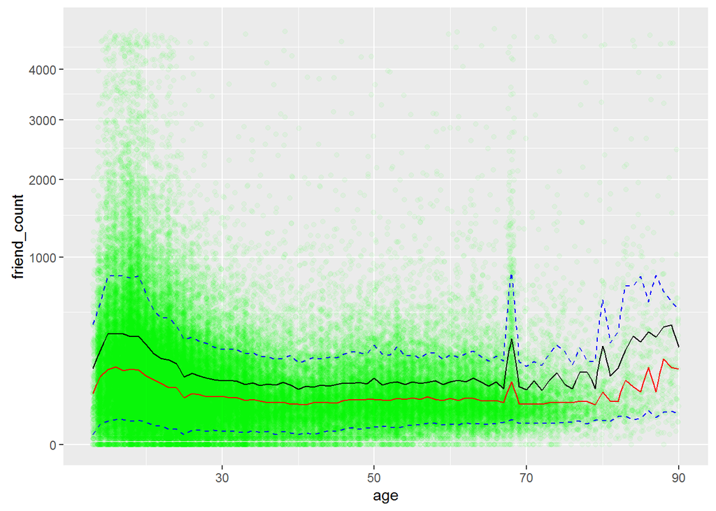

```r
ggplot(aes(age, friend_count), data = pf) +
  xlim(13, 90) +
  geom_point(alpha = 0.05,
             position = position_jitter(h=0),
             color = 'green') +
  coord_trans(y = "sqrt") +
  geom_line(stat = "summary", fun.y = mean) +
  geom_line(stat = "summary",
            fun.y = quantile,
            fun.args=list(probs=0.1),
            linetype = 2,
            color = "blue") +
  geom_line(stat = "summary",
            fun.y = quantile,
            fun.args=list(probs=0.9),
            linetype = 2,
            color = "blue") +
    geom_line(stat = "summary",
            fun.y = median,
            color = "red")
```

## Using Coord_cartesian

Coord_cartesian acts as visual zoom on the plot rather than modifying values outside the limits. To use it we need to get rid of xlim and coord_trans layers.

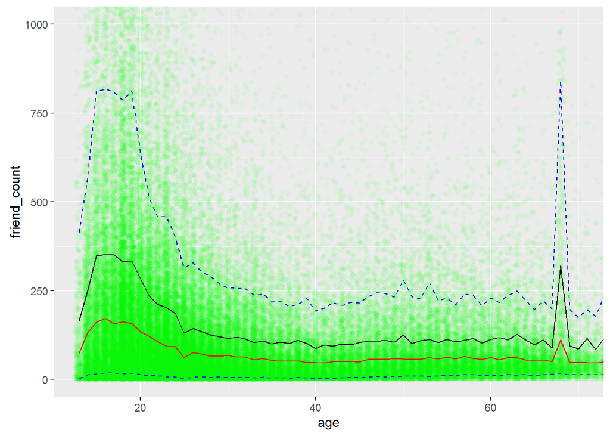

```r
ggplot(aes(age, friend_count), data = pf) +
  coord_cartesian(xlim = c(13,70), ylim = c(0,1000)) +
  geom_point(alpha = 0.05,
             position = position_jitter(h=0),
             color = 'green') +
  geom_line(stat = "summary", fun.y = mean) +
  geom_line(stat = "summary",
            fun.y = quantile,
            fun.args=list(probs=0.1),
            linetype = 2,
            color = "blue") +
  geom_line(stat = "summary",
            fun.y = quantile,
            fun.args=list(probs=0.9),
            linetype = 2,
            color = "blue") +
    geom_line(stat = "summary",
            fun.y = median,
            color = "red")
```

```r
ggsave('coord_cartesian_overlyaing.png', width = 12.8, height = 7.2, dpi = 300)
```

#### What are some of your observations of the plot?s

Response:

### Moira: Histogram Summary and Scatterplot

See the Instructor Notes of this video to download Moira’s paper on perceived audience size and to see the final plot.

Notes:

### Correlation

Notes: Describes the strength of relationship between any two variables.

```r
cor.test(pf$age , pf$friend_count, method = "pearson")
```

```
##
##  Pearson's product-moment correlation
##
## data:  pf$age and pf$friend_count
## t = -8.6268, df = 99001, p-value < 2.2e-16
## alternative hypothesis: true correlation is not equal to 0
## 95 percent confidence interval:
##  -0.03363072 -0.02118189
## sample estimates:
##         cor
## -0.02740737
```

```r
# another way of calculating is using the with function
with(pf, cor.test(age, friend_count, method = "pearson"))
```

```
##
##  Pearson's product-moment correlation
##
## data:  age and friend_count
## t = -8.6268, df = 99001, p-value < 2.2e-16
## alternative hypothesis: true correlation is not equal to 0
## 95 percent confidence interval:
##  -0.03363072 -0.02118189
## sample estimates:
##         cor
## -0.02740737
```

Look up the documentation for the cor.test function.

What’s the correlation between age and friend count? Round to three decimal places. Response:

### Correlation on Subsets

```r
# The method parameter is not used here because this funtion defaluts to pearson method.
with(subset(pf, pf$age <= 70 ), cor.test(age, friend_count))
```

```
##
##  Pearson's product-moment correlation
##
## data:  age and friend_count
## t = -52.592, df = 91029, p-value < 2.2e-16
## alternative hypothesis: true correlation is not equal to 0
## 95 percent confidence interval:
##  -0.1780220 -0.1654129
## sample estimates:
##        cor
## -0.1717245
```

Notes: The value comes out to be -0.17 which means age and friend_count is negatively correlated. As age increases, friend_count decreases. However, this does not imply any kind of causation.

### Correlation Methods

Notes: * “pearson”, the test statistic is based on Pearson’s product moment correlation coefficient cor(x, y) and follows a t distribution with length(x)-2 degrees of freedom if the samples follow independent normal distributions

- Kendall’s tau or Spearman’s rho statistic is used to estimate a rank-based measure of association. These tests may be used if the data do not necessarily come from a bivariate normal distribution.

## Create Scatterplots

Notes: Creating a scatter plot for two variables which are the number of likes recieved by the users and like recieved from desktop version of facebook as the source.

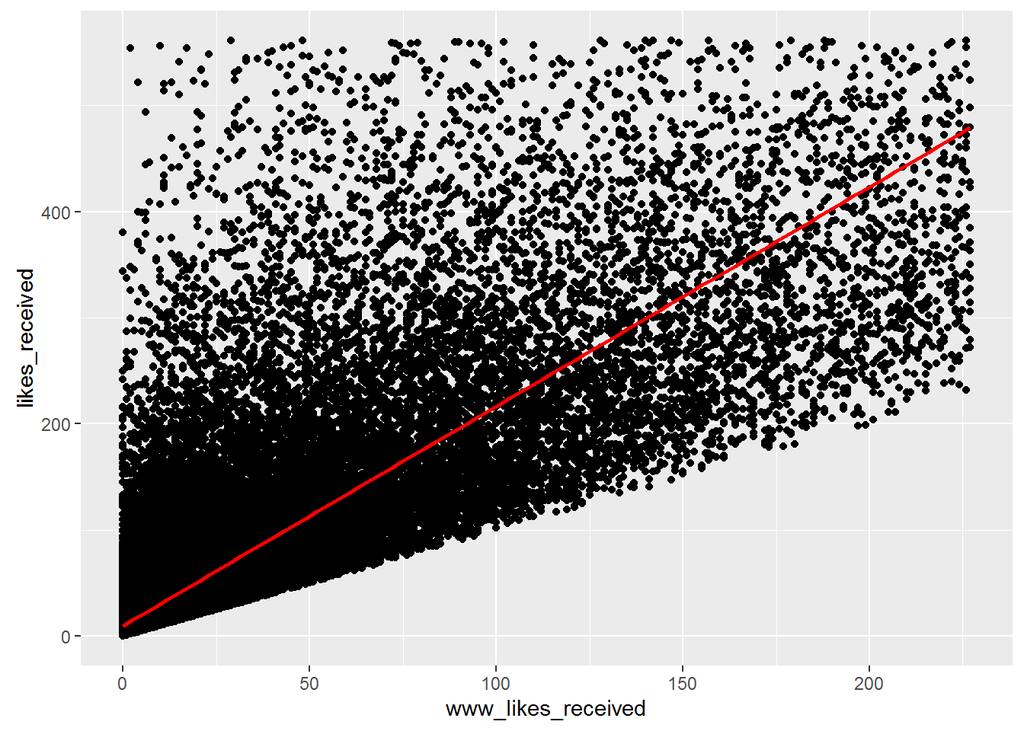

```r
ggplot(data = pf, aes(x = www_likes_received, y = likes_received)) +
  geom_point() +
  xlim(0, quantile(pf$www_likes_received, 0.95)) +
  ylim(0, quantile(pf$likes_received, 0.95)) +
  geom_smooth(method = "lm", color = "red")
```

### Strong Correlations

Notes: High correlation does not always mean it is good. In this case one was the subset of other hence may not be very useful.

```r
cor.test(pf$www_likes_received, pf$likes_received)
```

```
##
##  Pearson's product-moment correlation
##
## data:  pf$www_likes_received and pf$likes_received
## t = 937.1, df = 99001, p-value < 2.2e-16
## alternative hypothesis: true correlation is not equal to 0
## 95 percent confidence interval:
##  0.9473553 0.9486176
## sample estimates:
##       cor
## 0.9479902
```

```r
# Result: COrr = 0.948
```

What’s the correlation betwen the two variables? Include the top 5% of values for the variable in the calculation and round to 3 decimal places.

Response:

### Moira on Correlation

Notes:

### More Caution with Correlation

Notes:

```r
# install.packages('alr3')
library(alr3)
data(Mitchell)
```

Create your plot!

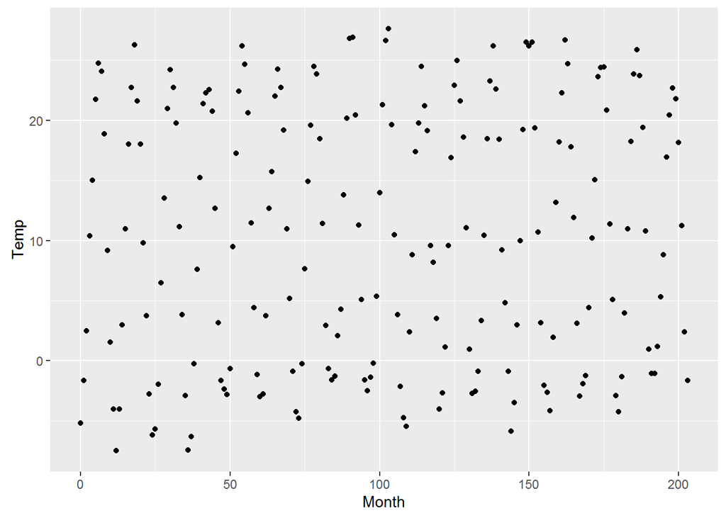

```r
ggplot(data = Mitchell, aes(x = Month, y = Temp)) + geom_point()
```

### Noisy Scatterplots

1. Take a guess for the correlation coefficient for the scatterplot.
2. What is the actual correlation of the two variables? (Round to the thousandths place)

```r
cor.test(Mitchell$Month, Mitchell$Temp)
```

```
##
##  Pearson's product-moment correlation
##
## data:  Mitchell$Month and Mitchell$Temp
## t = 0.81816, df = 202, p-value = 0.4142
## alternative hypothesis: true correlation is not equal to 0
## 95 percent confidence interval:
##  -0.08053637  0.19331562
## sample estimates:
##        cor
## 0.05747063
```

### Making Sense of Data

Notes:

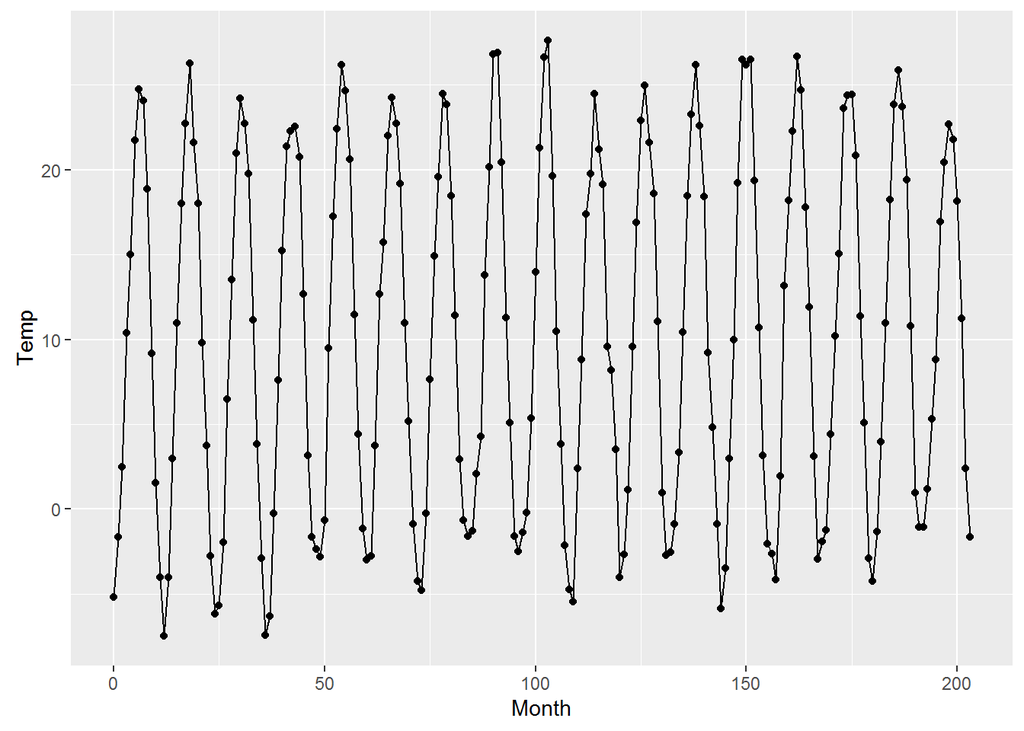

```r
ggplot(Mitchell, aes(Month, Temp)) +
  geom_point() + geom_line()
```

```r
  scale_x_continuous(breaks = seq(0, 203, 12))
```

```
## <ScaleContinuousPosition>
##  Range:
##  Limits:    0 --    1
```

### A New Perspective

You could also get perspective on this data by overlaying each year’s data on top of each other, giving a clear, generally sinusoidal graph. You can do this by using the R’s modulus operator %% in your code

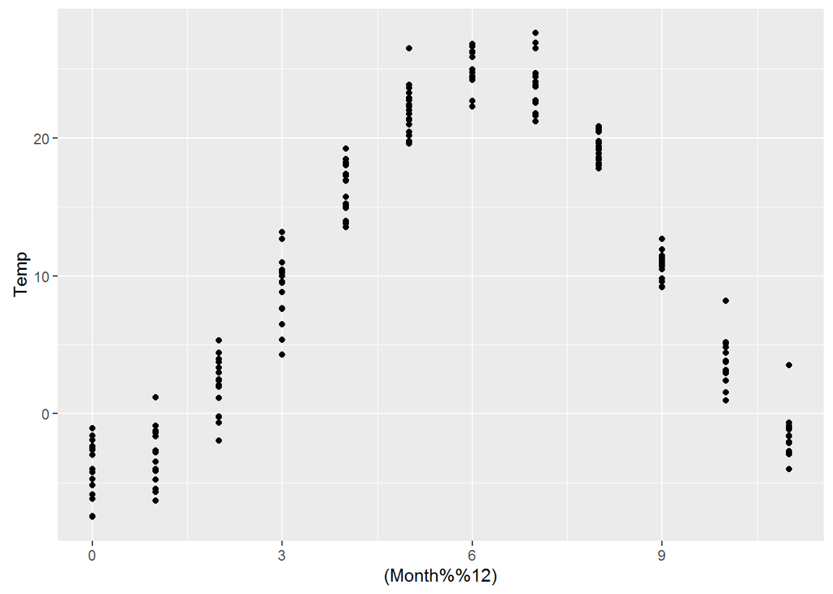

```r
ggplot(aes(x=(Month%%12),y=Temp),data=Mitchell)+
  geom_point()
```

What do you notice? Notes:

### Understanding Noise: Age to Age Months

Notes:

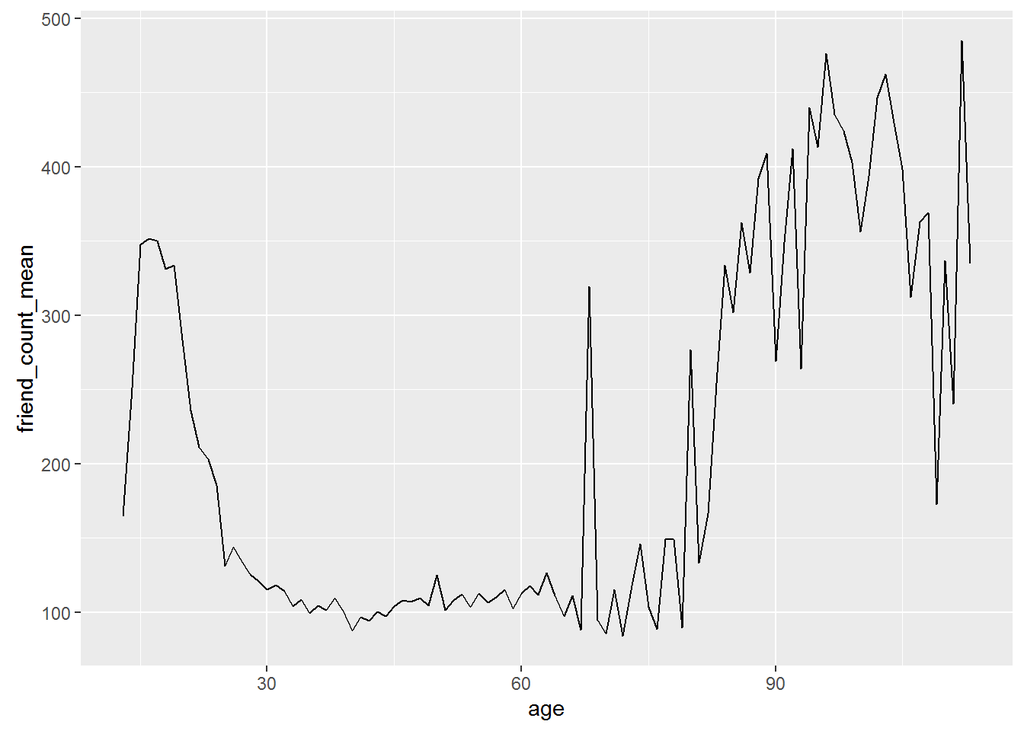

```r
ggplot(aes(x = age, y = friend_count_mean), data = pf.fc_by_age) + geom_line()
```

### Create an age with months variable

```r
pf$age_with_months <- pf$age - pf$dob_month/12 + 1

View(pf)
```

### Age with Months Means

```r
pf$age_with_months <- pf$age - pf$dob_month/12 + 1
```

Programming Assignment

```r
age_groups <- group_by(pf, age_with_months)
pf.fc_by_age_months <- summarise(age_groups,
                          friend_count_mean = mean(friend_count),
                          friend_count_median = median(friend_count),
                          n = n())
pf.fc_by_age_months <- arrange(pf.fc_by_age_months, age_with_months)
```

### Noise in Conditional Means

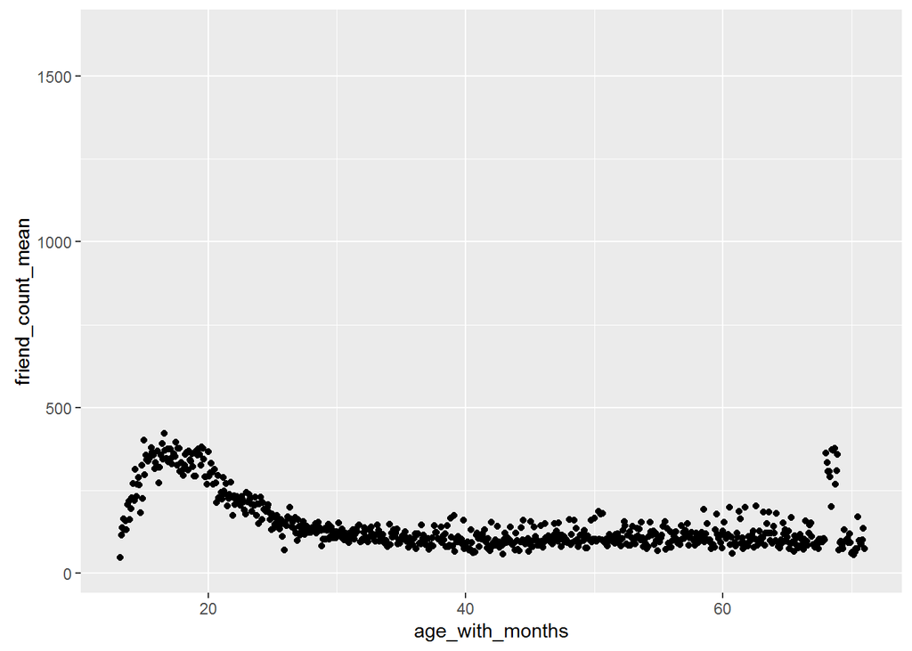

```r
ggplot(data = pf.fc_by_age_months, aes(x = age_with_months, y = friend_count_mean)) +
  geom_point() +
  xlim(13,71)
```

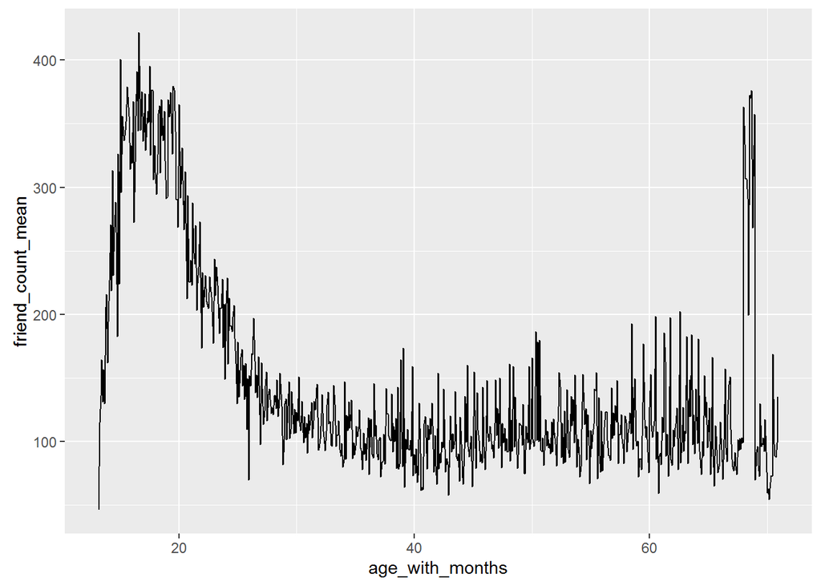

```r
## ALternatively
ggplot(aes(age_with_months, friend_count_mean), data = subset(pf.fc_by_age_months, age_with_months < 71)) + geom_line()
```

### Smoothing Conditional Means

Notes:

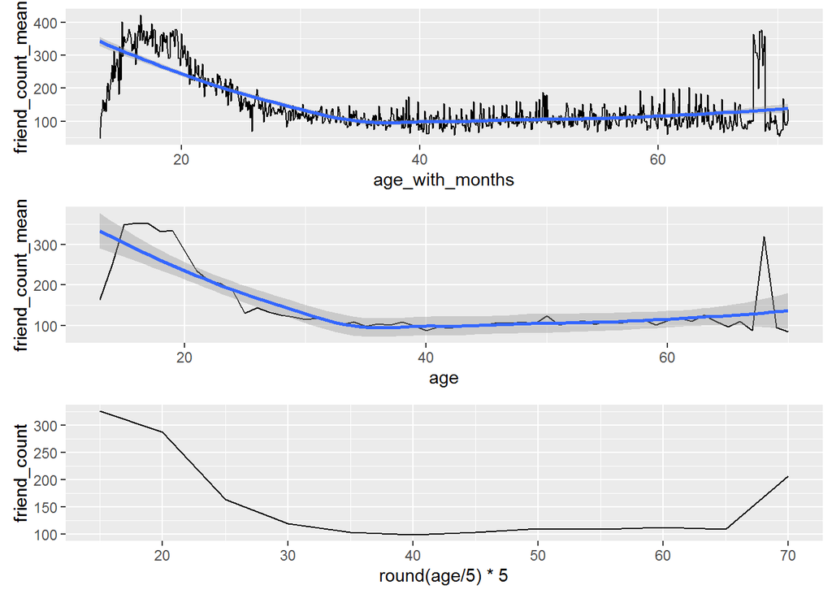

```r
p1 <- ggplot(aes(age, friend_count_mean), data = subset(pf.fc_by_age, age < 71)) + geom_line() + geom_smooth()

p2 <- ggplot(aes(age_with_months, friend_count_mean), data = subset(pf.fc_by_age_months, age_with_months < 71)) + geom_line() + geom_smooth()

p3 <- ggplot(data  = subset(pf, age < 71), aes(x = round(age / 5)*5, y = friend_count)) + geom_line(stat = "summary", fun.y = mean)


library(gridExtra)
grid.arrange(p2, p1, p3, ncol=1)
```

p3 has less data points and wider bin widths. By doing this we will estimate the mean more precisely but potentially miss important features of the age and friend_count relationship. These three plots are the examples of bias-variance trade-off and it is similar to the trade off we make while choosing bin width for histograms.

One way an analyst can make this trade off by using a flexible statistical model to smooth the estimates of conditional means. ggplot makes it easy to fit such models using geom_smooth. SO adding geom_smooth to the previous plots. ***

### Which Plot to Choose?

Notes:

### Analyzing Two Variables

Reflection:

Click **KnitHTML** to see all of your hard work and to have an html page of this lesson, your answers, and your notes!